# FLicc user guide: chapter preview

## 1.6 Residual diagnostics

FLicc is an equilibrium model: each year’s composition is explained by the equilibrium at that year’s F. Strong and weak year classes growing through the compositions are therefore expected to leave patterns in the residuals. The aim of the diagnostics is not to remove these patterns but to see them and judge their size, and to separate them from misfit that a setting can fix (selectivity, Linf, tail, effective sample size).

**Residuals.** `resid_flicc()` computes residuals consistent with the likelihood of the fit (effective sample size, observation model, tail cut, plus group):

- Pearson residuals, $r = (o - n\pi)/\sqrt{V}$, with $V = n\pi(1-\pi)$ for the multinomial and the same times $(n+\alpha_0)/(1+\alpha_0)$ for the Dirichlet-multinomial. They are easy to read in bubble plots but correlated within a composition and not normal for small expected counts.
- One-step-ahead (OSA) residuals: the composition is split, along increasing length, into a sequence of conditional binomials (beta-binomials for the Dirichlet-multinomial), and each observed count is turned into a randomized quantile residual $r = \Phi^{-1}(u)$. Under a correct model they are independent standard normal (Trijoulet et al. 2023), so QQ plots and tests are valid.

**How OSA residuals work.** A composition is not a set of independent numbers: with $n$ fish measured, a high count in one bin forces lower counts elsewhere. OSA residuals step through the bins of one composition, from small to large, and ask at each step a conditional question:

- bin 1: of all $n$ fish, how many should be in bin 1? Binomial$(n, \pi_1)$;
- bin 2: of the fish not in bin 1, how many should be in bin 2? Binomial$(n - o_1, \pi_2/(1-\pi_1))$; and so on. The last bin is determined by the others and has no residual.

The observed count is located in its predicted distribution: at the 97.5th percentile, $u = 0.975$ and $r = \Phi^{-1}(0.975) = 1.96$. Because counts are whole numbers, $u$ is drawn at random within the step of the distribution where the count falls (the “randomized” part). For the Dirichlet-multinomial the binomials are beta-binomials, so its extra variance is included.

“One step ahead” refers to stepping through the bins, not through time. In models with random effects, OSA residuals step through time and re-estimate the random effects at each step. FLicc has no random effects by default (F is estimated each year, the random walk is a penalty), so the expected compositions are fixed once the model is fitted and the residuals are exact and cheap.

Reading them:

- **Size**: about 5% beyond $\pm 2$, almost none beyond $\pm 3$.
- **Sign**: each residual is conditional on the smaller bins. A positive residual at length $L$ means that, of the fish still present at $L$ or larger, more were in bin $L$ than predicted: fish “drop out” faster than the model expects (higher mortality or falling selectivity), as in a catch curve. A negative residual means more fish carried on to larger sizes.
- **Spread**: an sd well above 1 means the data are noisier than the effective sample size and observation model allow (intervals too narrow); well below 1, that the noise is overstated.
- **Process variation**: the model does not include year-class strength, so strong and weak year classes appear as structure in the residuals (runs along the cohort tracks, mean-length runs) rather than as noise.
- **Few data per parameter**: residuals are computed at parameters estimated from the same data, so they shrink towards zero (sd below 1) when there are few data per parameter, e.g. a fit to a single year. A single year also gives no between-year diagnostics, and a year-class bump within one composition cannot be told apart from a selectivity misfit at those lengths. Across years, cohorts move along the growth tracks while selectivity misfit stays at the same length; the joint fit with shared selectivity is what lets the residuals separate the two.

```r
res_osa <- resid_flicc(fit, type = "osa")
c(mean = mean(res_osa$resid, na.rm = TRUE), sd = sd(res_osa$resid, na.rm = TRUE))
```

```
#>       mean         sd
#> 0.05655158 0.99622116
```

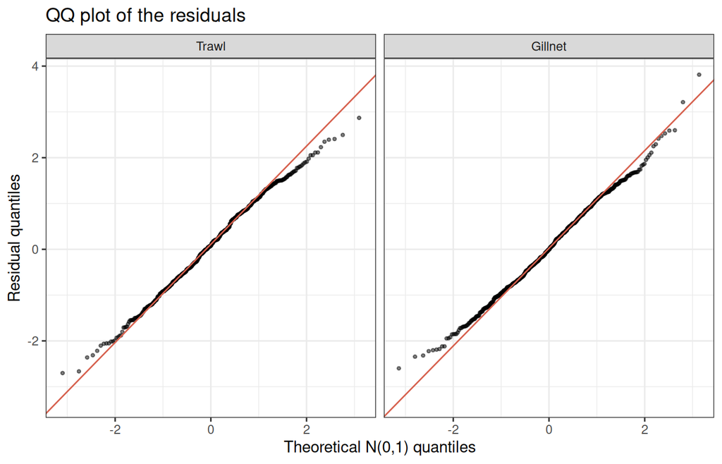

```r
plot_resid_qq(res_osa)
```

**Bubble plots.** Residuals by length and year; blue where more fish were observed than expected, red where fewer. `cohorts = TRUE` adds von Bertalanffy growth tracks of year classes (grey lines):

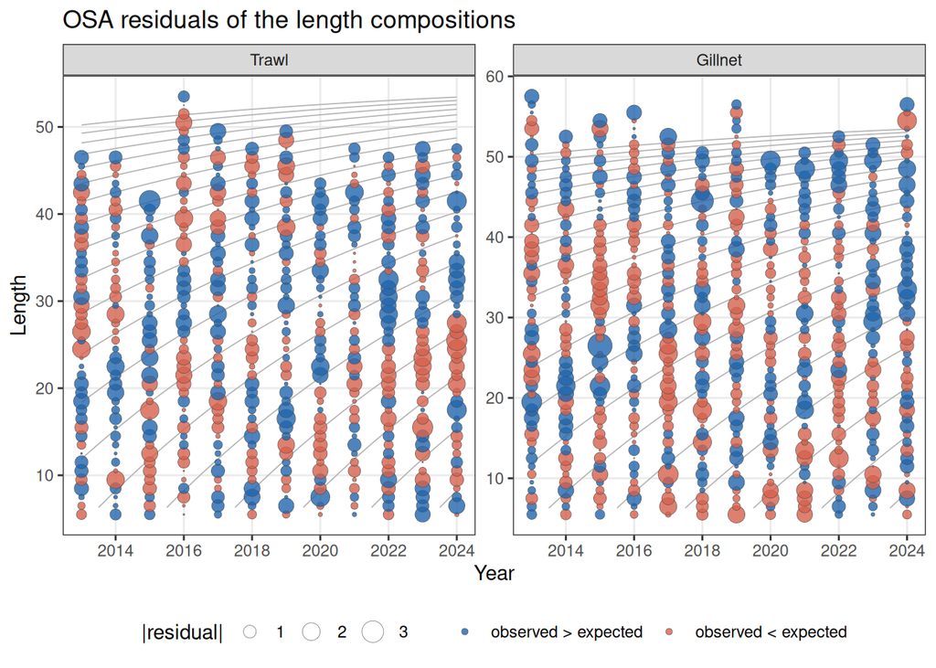

```r
plot_resid_bubble(res_osa, fit = fit, cohorts = TRUE)
```

**Residuals by length.** `plot_resid_len()` draws the residuals against length as bars, with the same panels as `plot_len()`: one panel per year and gear (`year =`, `gear =` select them), the gears pooled with `by_gear = FALSE`, or the years pooled with `pool_years = TRUE`. Pooled residuals are summed and divided by $\sqrt{k}$ (for $k$ residuals per bin), so the dashed lines at $\pm 2$ keep their meaning.

Pooled over all years, year classes largely cancel out, and what remains is misfit at the same lengths in every year: the selectivity shape, or Linf and CVL in the largest fish. This is the first plot to look at:

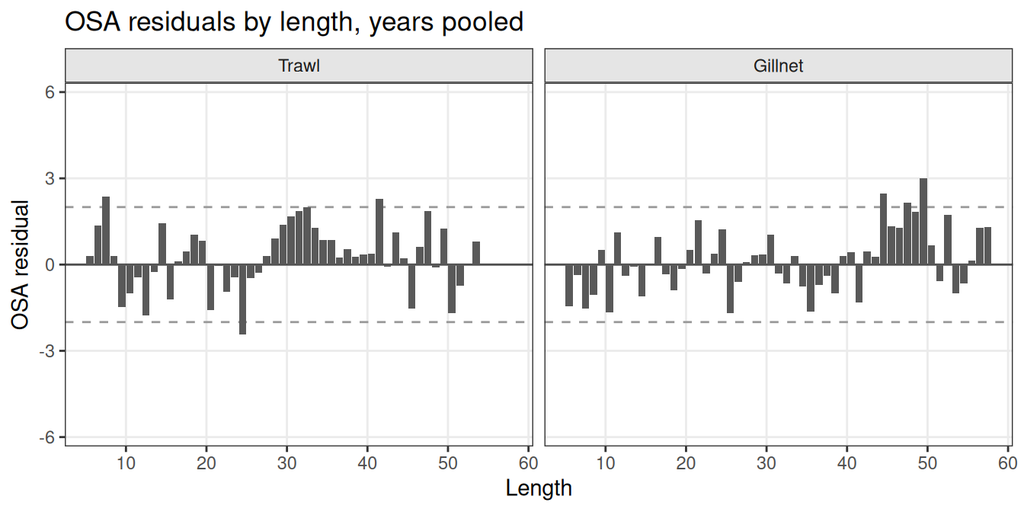

```r
plot_resid_len(res_osa, pool_years = TRUE)
```

Here two runs stand out. In the trawl, the OSA residuals are positive from about 28 to 35 cm: of the fish at these lengths or larger, more stop at each length than predicted, i.e. the trawl catches fewer fish above 35 cm than the fitted dome allows (its right limb falls more steeply). In the gillnet, positive residuals from about 45 to 50 cm say the same for the largest fish: fewer reach the largest lengths than predicted, which points to Linf or CVL (the growth of the largest fish), to a slight dome of the gillnet, or to a higher F on the largest fish. Both runs are at the same lengths in every year (below), so they are not year classes.

By year, a misfit that moves to larger lengths from one year to the next is a year class growing through; one that stays at the same length is selectivity. The last three years, as OSA and as Pearson residuals:

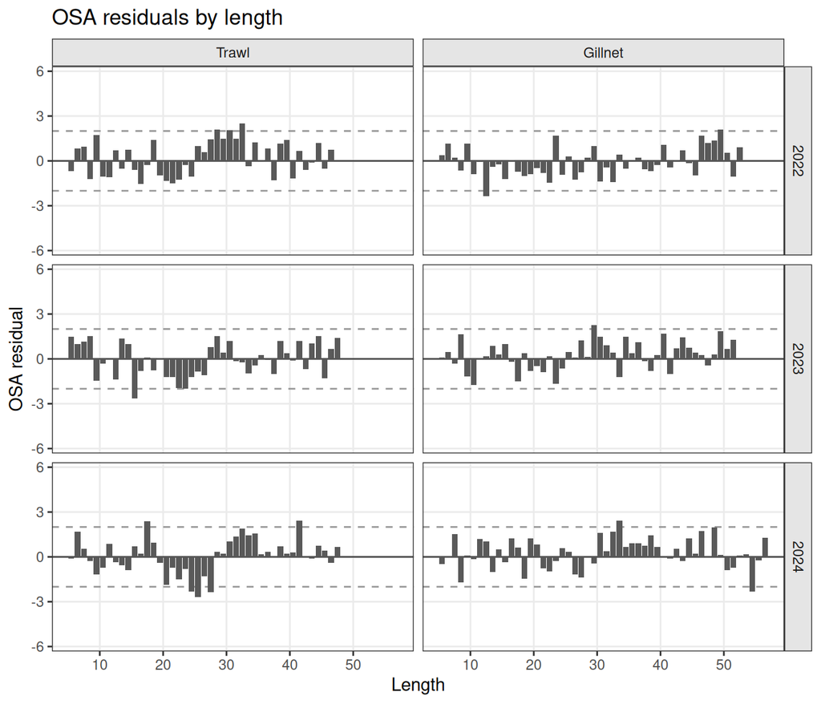

```r
plot_resid_len(res_osa, year = 2022:2024)
```

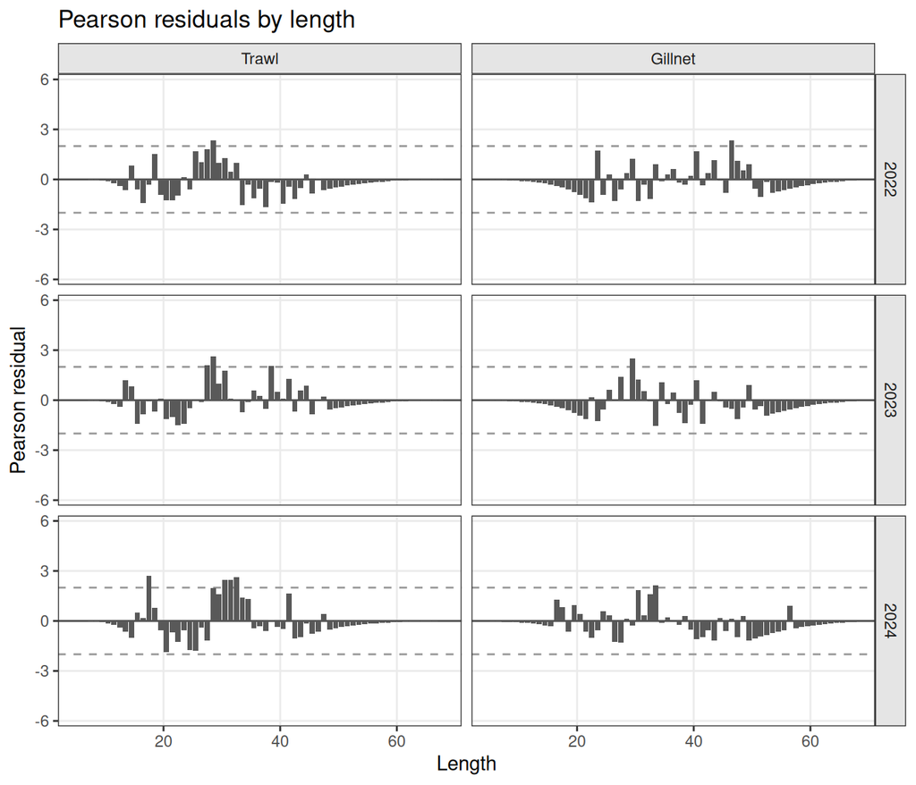

```r
plot_resid_len(fit, type = "pearson", year = 2022:2024)
```

The trawl run at about 30-35 cm is there in all three years, together with a deficit at about 20-28 cm, as OSA and as Pearson residuals: a shape the trawl selectivity does not follow, not a year class (which would move by a few cm per year). In the Pearson panels, the long rows of small negative bars at both ends of each panel are the empty bins beyond the observed fish: they carry no information.

**Pearson or OSA?** Both measure how far the observed count in a bin is from its expectation, in standard deviations, but they answer different questions:

|  | Pearson | OSA |
| --- | --- | --- |
| Question | Is the count in this bin far from $n\pi$? | Given the fish in the smaller bins, is the count in this bin unusual? |
| Independence | correlated within a composition (they sum to about zero: a misfit at one length forces opposite residuals elsewhere) | independent under a correct model |
| Distribution | skewed for small expected counts: observed zeros give small negative values, one fish where 0.05 are expected gives about +4 | standard normal, also for small counts |
| Tails | drawn for every bin, so the empty bins beyond the largest fish form a fringe of small negative bars | end at the largest fish of each composition (and the last bin has none) |
| Randomness | none | a random draw within each count’s step (`seed`): small details change with the seed, patterns do not |
| Use | bubble plots, a quick look at where the fit is high or low | QQ plot, sd, tests, the $\pm 2$ rule |

In practice: read patterns with either, judge size and significance with OSA. A pattern that shows in both (e.g. too few fish at one range of lengths and too many at the next) is real. A single large Pearson residual at the largest lengths that is small as OSA residual is one rare fish, not a misfit.

The sign of an OSA residual is conditional: a positive residual at length $L$ means that, of the fish at $L$ or larger, more were in bin $L$ than predicted. A run of negative OSA residuals followed by a run of positive ones therefore marks a dip followed by a surplus in the composition, e.g. a second mode or a year class at the larger lengths.

**Mean length and runs test.** The observed mean length of each composition is compared with its expectation, standardized with the standard error implied by the observation model (Francis 2011). A runs test checks whether the residuals change sign as often as random residuals would; too few runs mean systematic structure (green background: passed; red: failed; limits at three standard deviations, as in `ss3diags` and JABBA):

```r
lmr <- lmean_resid_flicc(fit)
lmr$runs
```

```
#>            gear p_value pass sd_z
#> Trawl     Trawl   0.409 TRUE 1.29
#> Gillnet Gillnet   0.965 TRUE 1.09
```

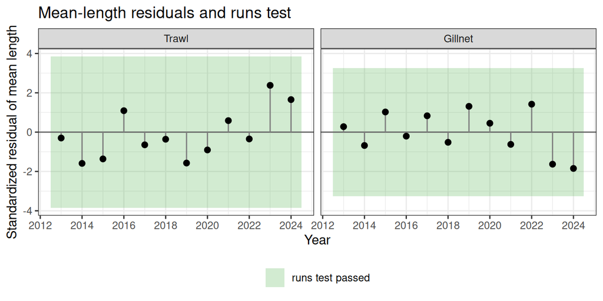

```r
lmr$plot
```

**Posterior predictive checks.** The fitted curve in `plot_len()` never matches the bars exactly, because every sample of fish is noisy. The question is whether the differences are larger than that noise. A posterior predictive check answers it by simulation: if the fitted model were true, what could a new sample of the same size look like? `ppc_flicc()` draws 300 such samples for every gear and year, from the fitted composition and with the observation model and effective sample size of the fit. The spread of these samples is what the model expects from sampling alone; the observed data should look like one more of them. (With `par_draws = TRUE` the parameters are also drawn from their estimated uncertainty, which widens the spread slightly.)

**Look at the compositions first.** `plot_ppc_lfd()` shows, for each length bin, the observed proportion (bar) and the range the model expects for it (line: 95% of the simulated samples; point: their median). A bar inside its line differs from the fit by no more than sampling noise; a red bar is outside it. Start with all years pooled, which shows the average shape the model has to reproduce, i.e. selectivity and growth:

```r
ppc <- ppc_flicc(fit, nsim = 300)
ppc
```

```
#> Posterior predictive check of the length compositions: 300 replicates, plug-in
#>
#> Share of observed statistics outside the 95% predictive interval:
#>     gear  stat share_outside_95
#>    Trawl Lmean             0.08
#>  Gillnet Lmean             0.08
#>    Trawl   L95             0.08
#>  Gillnet   L95             0.08
#>    Trawl  Pmat             0.08
#>  Gillnet  Pmat             0.08
#>    Trawl  Lmax             0.00
#>  Gillnet  Lmax             0.25
#>
#> Share of length bins outside the 95% predictive interval:
#>     gear share_bins_outside_95
#>    Trawl                  0.03
#>  Gillnet                  0.02
#>
#> Plots: $plot (statistics by year), $plot_lfd or plot_ppc_lfd() (compositions)
```

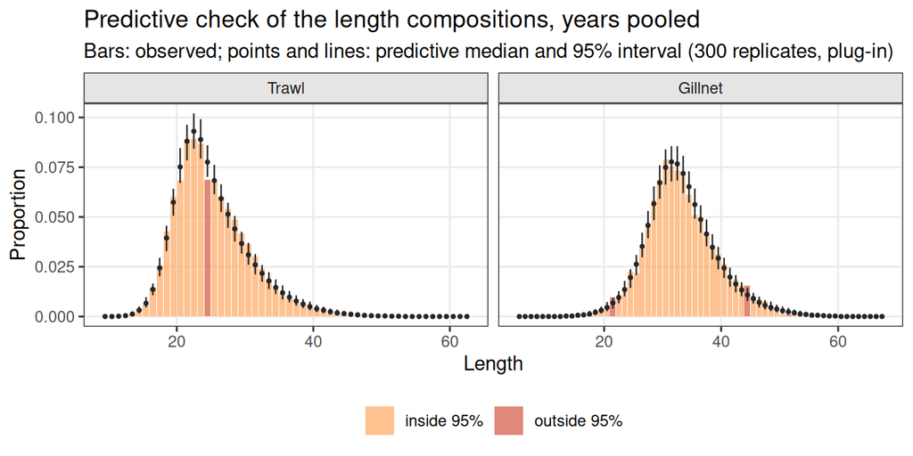

```r
plot_ppc_lfd(ppc, pool_years = TRUE)
```

Read the pooled panels in three steps:

1. **Count the red bars.** About 1 bin in 20 is outside its 95% range by chance. Here 3% of the bins are red for Trawl and 2% for Gillnet (`ppc$coverage_bins`, all years).
2. **Look at where they are.** Single red bars scattered along the axis are chance. Several neighbouring bars on the same side of the intervals mean the shape is wrong: bars above the intervals on the left of the mode mean more small fish than the selectivity allows (the ascending limb is too steep or too far to the right); bars above the intervals in the right-hand tail mean more large fish than the dome or Linf allow; bars below mean the opposite.
3. **Compare the scatter with the intervals.** If the bars jump around inside wide intervals, the observation model allows for that noise; if the intervals are narrow and bars fall outside on both sides, the effective sample size is too high and the confidence intervals of the assessment will be too narrow.

Then look at single years. Here, the last four:

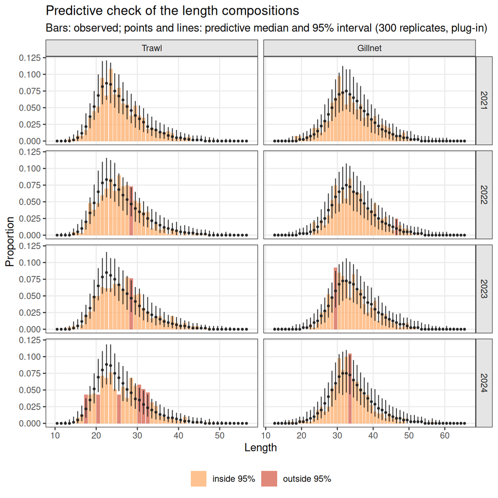

```r
plot_ppc_lfd(ppc, year = yr4)
```

Red bars in the same place in most years repeat what the pooled plot shows: a misfit of selectivity or growth. Red bars concentrated in one year are a different matter. In 2024 the trawl composition has 6 red bins between 17 and 32 cm, with bars above the intervals next to bars below: that year, more fish fall in some length ranges and fewer in others than the model predicts. This is the signature of a strong (or weak) year class passing through the fishery. The model assumes steady recruitment and cannot follow such pulses; it averages over them. When the pooled plot shows few red bars, as here, the average is unbiased and the year-to-year pulses are no reason to change the model.

The plot is the visual counterpart of the residual plots above: the residuals give the same misfit as numbers per bin, scaled by the expected noise, and the OSA residuals are the formal test. The predictive check shows the misfit in the units of the data, which makes it the easiest to explain; since the data were also used to fit the model, it detects clear misfit rather than subtle departures.

**Summary statistics.** The same simulated samples give the predictive distribution of four statistics per gear and year: mean length, 95th percentile, proportion of mature fish and largest length (`ppc$coverage`, share of years outside the 95% range):

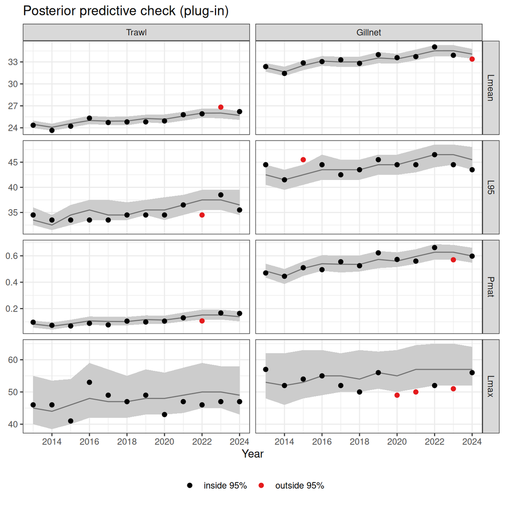

```r
ppc$plot
```

In this fit the OSA residuals have sd 1, so the bin-to-bin noise within a year is close to what the observation model allows. The mean lengths, however, vary between years with an sd of 1.29 (trawl) and 1.09 (gillnet) in standardized units, and 8% and 8% of the observed mean lengths lie outside their 95% predictive intervals. Where the between-year variation is large while the within-year noise is not, the misfit is not sampling noise: whole compositions shift between years, as year classes pass through, which the equilibrium model cannot follow.

About 5% of the observed values should lie outside the 95% intervals. Many more means that the effective sample size or the observation model understate the variability of the data, so the intervals of the assessment are too narrow; far fewer means the effective sample size could be higher.

| Pattern | Likely cause | Response |
| --- | --- | --- |
| Diagonal runs of one sign along the cohort tracks; mean-length runs test failed | strong or weak year classes (expected in an equilibrium model) | report it; check that status is robust (retrospective, tail cut); do not over-fit |
| Vertical bands of one sign at the same lengths in all years | selectivity shape | logistic vs dome; dome sensitivity |
| Misfit of the largest fish in all years | Linf, CVL or doming | Linf sensitivity, tail cut |
| A change of sign between periods | change of selectivity, gear or sampling | split periods; `by_year` check |
| Many observed statistics outside the predictive intervals | ESS too high, or observation model too narrow | lower ESS; Dirichlet-multinomial |
| OSA residuals with sd well above 1 | the same | the same |

## 1.7 Check 9: retrospective consistency

The model is refitted with the last one, two and three years removed (`peels`); `Map()` runs one fit per peel. Mohn’s rho compares the terminal SPR of each peel with the SPR of the same year in the full fit.

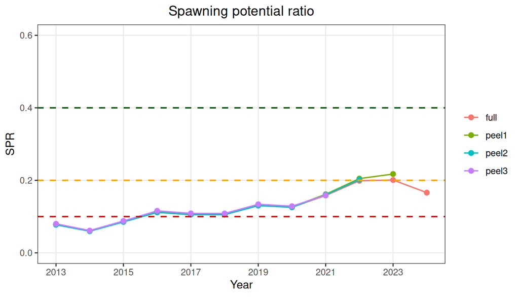

```r
yrs <- as.numeric(dimnames(lfd[[1]])$year)
peels <- 1:3

retro <- Map(function(p) {
  fiticc(lfd, stklen, sel_fun = sel_fun, catch_by_gear = cbg,
         settings = list(CVL = 0.1, obs_model = "dm", dm_theta = "saturating"),
         years = head(yrs, -p), se = FALSE)
}, peels)
names(retro) <- paste0("peel", peels)
plot_spr(c(list(full = fit), retro))
```

```r
spr_full <- c(fit$report$spr)
spr_peel <- sapply(retro, sprcur_flicc)               # terminal SPR of each peel
spr_same <- spr_full[length(spr_full) - peels]        # same years in the full fit
mohn_rho <- mean((spr_peel - spr_same) / spr_same)
round(mohn_rho, 3)
```

```
#> [1] 0.034
```

| **Pass** | Mohn’s rho for SPR within about ±0.2. |
| --- | --- |
| **Red flags** | Consistent revisions in one direction (the terminal SPR is systematically revised up or down). |
| **Action** | Check for trends in selectivity or sampling; in a rebuild, an equilibrium model is expected to under-estimate SPR at the end of the series (section *Lag under changing F*). |